# Texto 5 - Presença de docentes negros no ensino superior e outras ocupações qualificadas

Pablo Castro

2026-06-19

# 1 Introdução

A presença de docentes negros no ensino superior constitui indicador fundamental para avaliar a equidade racial no ambiente acadêmico e nas ocupações de alta qualificação no Brasil. Este texto, quinto do conjunto de nove análises temáticas previstas no Contrato IC nº 000199/2025-0, integra o Produto 3 e foca especificamente na composição racial do corpo docente universitário, com análises comparativas sobre segregação ocupacional e barreiras ao acesso e progressão da população negra em posições de maior prestígio.

Em conformidade com o Plano de Trabalho Geral, a análise utiliza microdados do Censo da Educação Superior (INEP, 2014-2024) e do Censo Demográfico 2022 (IBGE) para construir indicadores sobre representação racial entre docentes, comparações com a população formada em nível superior, diferenças entre redes de ensino (pública e privada), distribuição por áreas de formação e níveis de titulação. Os resultados evidenciam o fenômeno do “teto de vidro” e padrões persistentes de sub-representação negra em posições acadêmicas, mesmo diante do crescimento no acesso da população negra ao ensino superior nos últimos anos.

A análise é complementada por um recorte municipal da sub-representação negra entre pessoas com nível superior de graduação concluído, a partir de dados do Censo 2022 desagregados por município, permitindo identificar a heterogeneidade territorial dessa desigualdade além das médias nacionais e regionais.

# 2 Composição Racial do Corpo Docente no Ensino Superior

Esta seção apresenta uma análise detalhada da composição racial dos docentes do ensino superior no Brasil, examinando diferenças entre redes de ensino, evolução temporal, níveis de titulação e distribuição regional. Os dados revelam padrões estruturais de desigualdade racial que persistem apesar da expansão do acesso da população negra à educação superior.

## 2.1 Composição Racial por Rede de Ensino

A Figura 2.1 apresenta a composição racial do corpo docente segundo a rede de ensino (privada e pública) em 2024. Os resultados evidenciam significativa sub-representação da população negra entre os docentes universitários em ambas as redes, com disparidades particularmente acentuadas na rede privada.

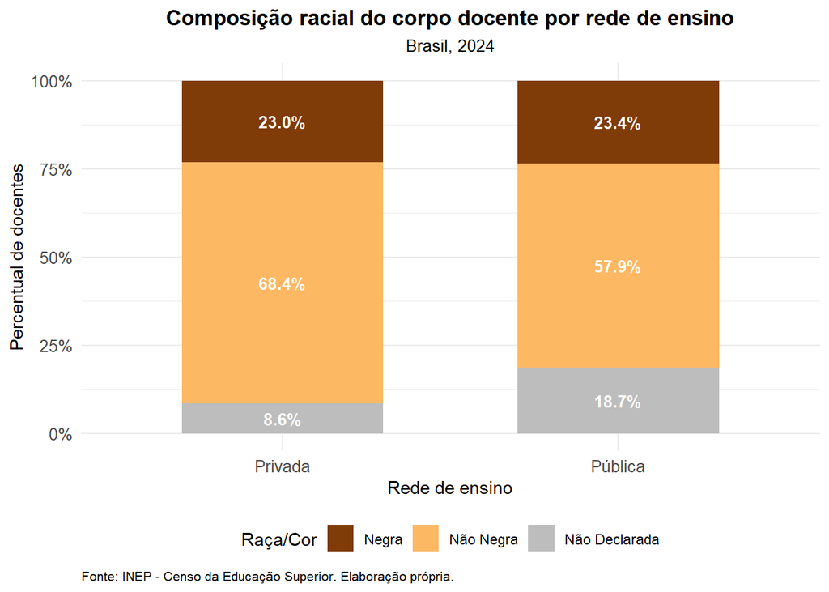

Figure 2.1: Composição Racial por Rede de Ensino

Na rede privada, apenas 23,0% dos docentes são negros (pretos e pardos), enquanto 68,4% são não negros e 8,6% não declararam raça/cor. Na rede pública, a participação negra é ligeiramente superior, alcançando 23,4%, com 57,9% de docentes não negros e 18,7% sem declaração racial. Esses percentuais contrastam fortemente com a composição demográfica brasileira, onde a população negra representa aproximadamente 56% do total.

A maior proporção de docentes negros na rede pública (23,4%) em comparação à privada (23,0%) pode estar associada à implementação da Lei de Cotas para concursos públicos federais (Lei 12.990/2014), que reserva 20% das vagas em concursos públicos para candidatos negros. No entanto, mesmo na rede pública, a representação negra permanece muito aquém da proporção populacional, indicando que barreiras estruturais ao acesso e à progressão na carreira acadêmica continuam operando de forma significativa.

## 2.2 Evolução Temporal da Participação de Docentes Negros

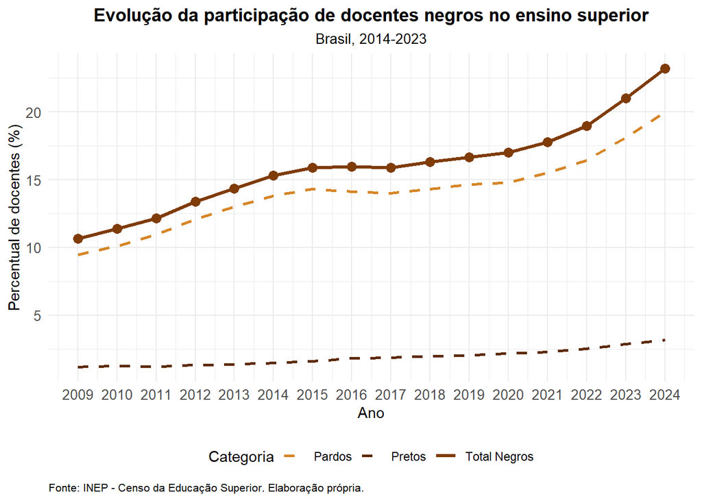

Figure 2.2: Evolução Temporal da Participação de Docentes Negros

Em 2009, docentes negros representavam 10,7% do total, percentual que cresceu para 23,2% em 2024. Esse aumento de 12,5 pontos percentuais em 15 anos representa mais que duplicação da participação negra no período. Entre os docentes pardos, a participação passou de aproximadamente 9,5% em 2009 para cerca de 20% em 2024, enquanto entre docentes pretos o crescimento foi de aproximadamente 1,2% para 3,2% no mesmo período.

Apesar do crescimento significativo ao longo da série histórica, observando-se aceleração após 2020, o ritmo de aumento indica que, se mantido constante, levará décadas para que a proporção de docentes negros se equipare à composição demográfica brasileira. A participação de docentes pretos permanece particularmente baixa (3,2%), correspondendo a menos de um terço da proporção de pessoas pretas na população brasileira (10,2%), evidenciando que as barreiras ao acesso e progressão na carreira acadêmica afetam de forma ainda mais intensa esse segmento da população negra.

## 2.3 Composição Racial Histórica do Corpo Docente

A Figura 2.3 apresenta a composição racial detalhada do corpo docente entre 2009 e 2024, incluindo a categoria “Não Declarada”. A análise revela importantes transformações na coleta e declaração de dados raciais, além do crescimento da participação negra ao longo do período.

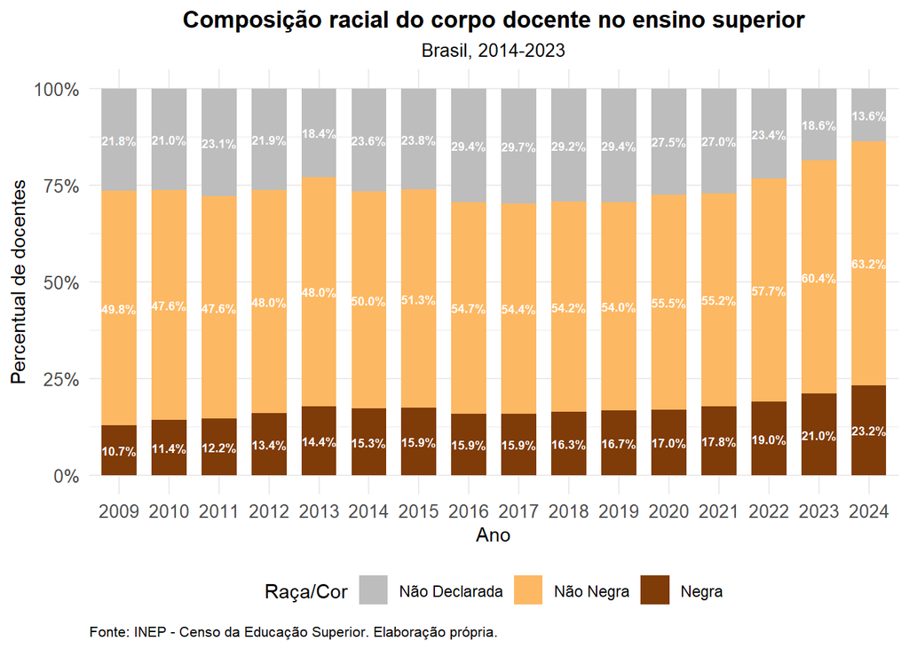

Figure 2.3: Composição Racial Histórica do Corpo Docente

## 2.4 Composição Racial por Nível de Titulação

A Figura 2.4 apresenta a composição racial dos docentes segundo o nível de titulação (doutorado e mestrado) em 2024. Os resultados evidenciam que a sub-representação negra ocorre em ambos os níveis, com ligeiras diferenças entre eles.

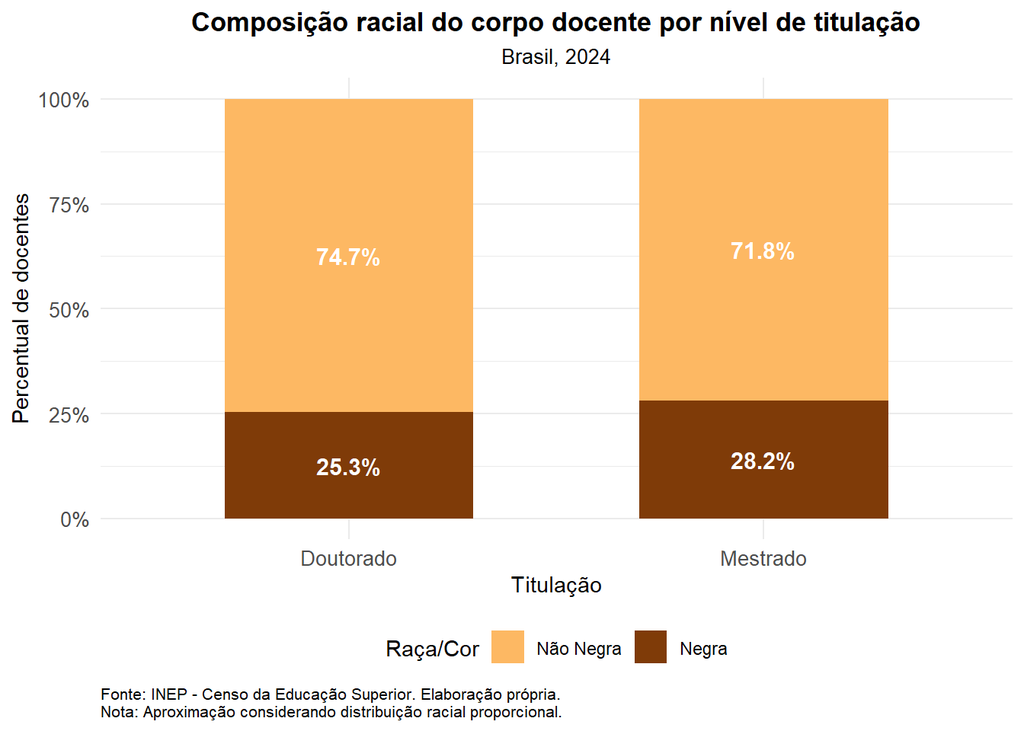

Figure 2.4: Composição Racial por Nível de Titulação

Entre docentes com doutorado, 25,3% são negros, 74,7% são não negros. Entre aqueles com mestrado, a participação negra é de 28,2%, enquanto 71,8% são não negros. A maior proporção de docentes negros entre mestres (28,2%) em comparação a doutores (25,3%) sugere a existência de barreiras adicionais na progressão para os níveis mais elevados da carreira acadêmica.

Essa diferença de 2,9 pontos percentuais, embora pareça pequena, indica um padrão de afunilamento racial à medida que se avança na hierarquia acadêmica. Docentes negros enfrentam maiores dificuldades para concluir o doutorado e, consequentemente, para ascender a posições de maior prestígio e remuneração no ambiente universitário. Fatores como menor acesso a bolsas de pós-graduação, necessidade de conciliar estudo e trabalho, menor inserção em redes acadêmicas e discriminação racial contribuem para esse fenômeno.

# 3 Segregação Ocupacional por Área de Formação

Esta seção examina como a população negra se distribui entre as diferentes áreas de formação superior, evidenciando padrões de segregação ocupacional que refletem desigualdades estruturais no acesso a campos profissionais de maior prestígio e remuneração.

## 3.1 Distribuição Municipal de Pessoas Negras com Ensino Superior Completo

A análise nacional e por área de formação apresentada nas próximas subseções pode mascarar diferenças importantes entre municípios. A Figura 3.1 apresenta o percentual de pessoas negras entre aquelas com nível superior de graduação concluído, por município, a partir do Censo Demográfico 2022, considerando apenas municípios com pelo menos 100 pessoas formadas (para evitar percentuais instáveis em municípios com poucos casos).

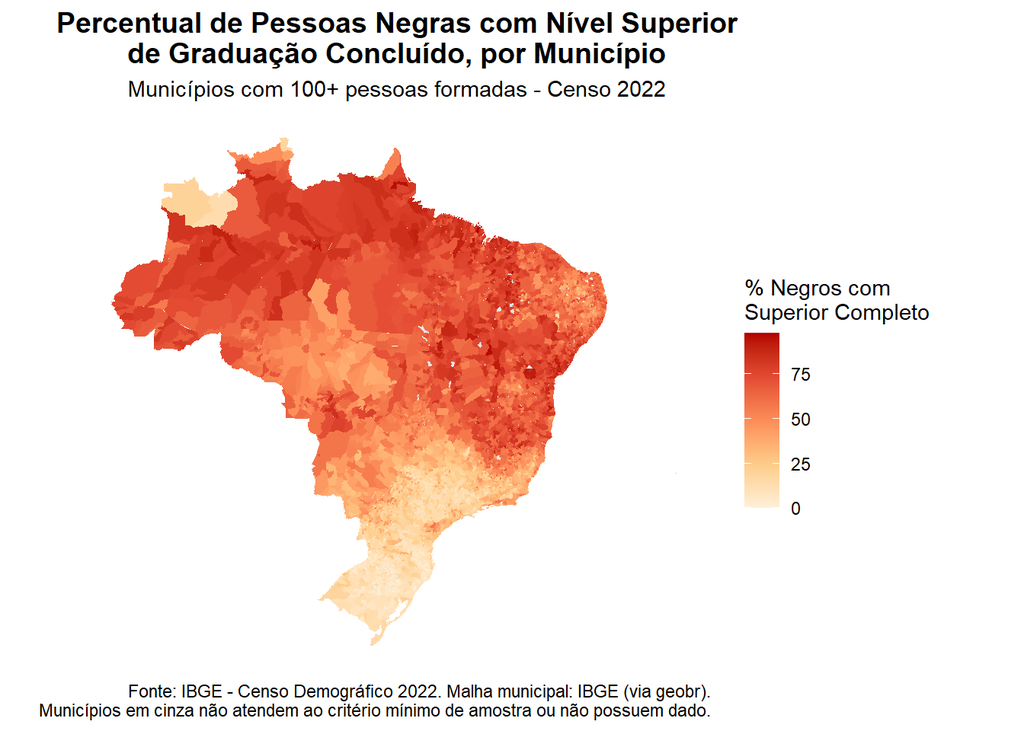

Figure 3.1: Percentual de Pessoas Negras com Nível Superior de Graduação Concluído, por Município

O mapa revela heterogeneidade territorial substancial: a sub-representação negra entre formados em nível superior, já evidenciada nas médias nacionais e regionais, varia consideravelmente entre municípios, mesmo dentro de uma mesma região, reforçando a necessidade de políticas de acesso e permanência ao ensino superior sensíveis ao território, e não apenas a recortes nacionais ou regionais agregados.

## 3.2 Percentual de Pessoas Negras por Área de Formação

A Figura 3.2 apresenta o percentual de pessoas negras entre as pessoas com pelo menos nível superior de graduação concluído, por área de formação, utilizando dados do Censo Demográfico 2022. Os resultados revelam significativa heterogeneidade na representação negra entre as diferentes áreas do conhecimento.

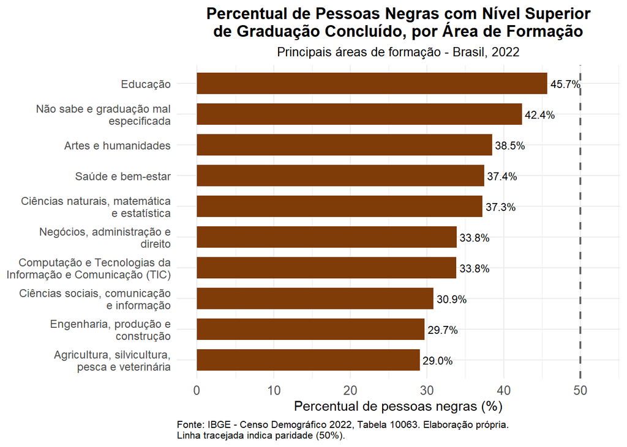

Figure 3.2: Percentual de Pessoas Negras com Nível Superior de Graduação Concluído, por Área de Formação

A área de Educação apresenta a maior proporção de pessoas negras entre os formados (45,7%), seguida pela categoria “Não sabe e graduação mal especificada” (42,4%). Em seguida aparecem Artes e Humanidades (38,5%), Saúde e Bem-estar (37,4%), e Ciências Naturais, Matemática e Estatística (37,3%). As áreas com menor representação negra são Agricultura, Silvicultura, Pesca e Veterinária (29,0%), Engenharia, Produção e Construção (29,7%), e Ciências Sociais, Comunicação e Informação (30,9%).

Todas as áreas apresentam percentuais de pessoas negras inferiores à proporção populacional (56%), evidenciando que, mesmo com a expansão do acesso ao ensino superior, a população negra permanece sub-representada em todas as grandes áreas do conhecimento. A linha tracejada no gráfico indica o ponto de paridade (50%), destacando que nenhuma área alcança representação proporcional à composição demográfica. A concentração de pessoas negras em áreas como Educação e a menor presença em Engenharia e áreas tecnológicas reflete padrões históricos de segregação ocupacional que direcionam a população negra para profissões de menor remuneração e prestígio social.

## 3.3 Gap de Representação por Área de Formação

A Figura 3.3 apresenta o gap (lacuna) de representação da população negra por área de formação, calculado como a diferença entre a proporção de negros em cada área e a proporção populacional (56%). Valores negativos indicam sub-representação.

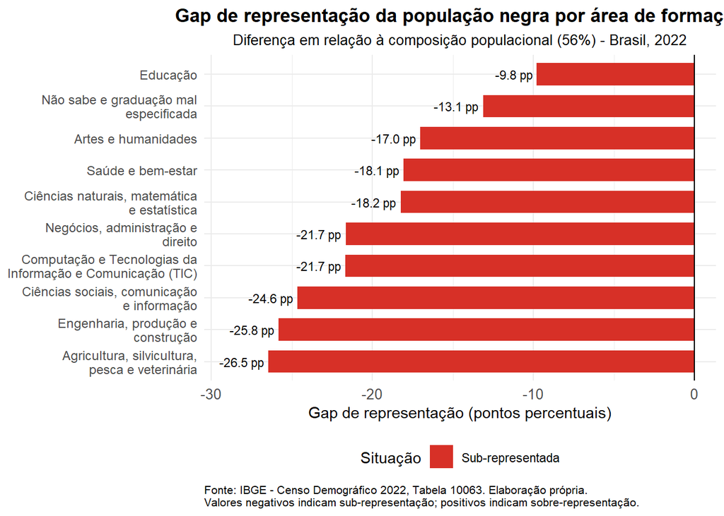

Figure 3.3: Gap de Representação por Área de Formação

Esses resultados evidenciam que a segregação ocupacional por raça se manifesta de forma particularmente intensa nas áreas associadas a maior remuneração e prestígio social. Engenharia, áreas tecnológicas e agrárias, tradicionalmente mais valorizadas no mercado de trabalho, apresentam os maiores déficits de representação negra. Esse padrão reflete barreiras estruturais ao longo de toda a trajetória educacional, desde a educação básica — onde estudantes negros têm menor acesso a escolas de qualidade e a áreas como matemática e ciências — até o ensino superior, onde enfrentam dificuldades adicionais de permanência em cursos mais concorridos e demandantes.

# 4 O Fenômeno do “Teto de Vidro” na Carreira Acadêmica

Esta seção examina o afunilamento da participação negra ao longo da progressão acadêmica, fenômeno conhecido como “teto de vidro”, que evidencia barreiras invisíveis mas persistentes à ascensão de pessoas negras em posições de maior qualificação e prestígio.

## 4.1 Afunilamento ao Longo da Carreira Acadêmica

A Figura 4.1 apresenta o percentual de pessoas negras em diferentes etapas da trajetória acadêmica: população geral, ensino superior completo, docentes do ensino superior e docentes com doutorado. A análise revela dramático afunilamento da participação negra à medida que se avança na hierarquia acadêmica.

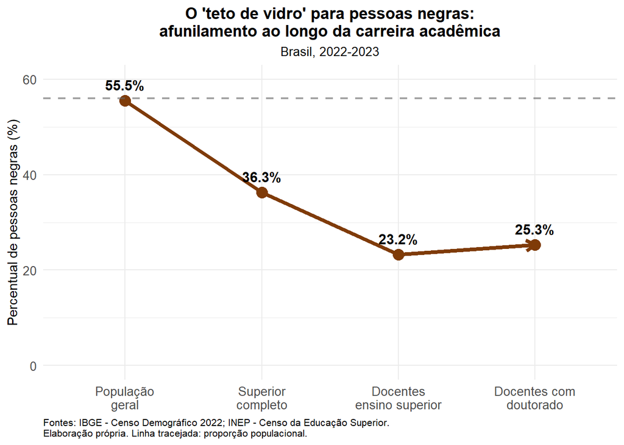

Figure 4.1: Afunilamento ao Longo da Carreira Acadêmica

Pessoas negras representam 55,5% da população geral brasileira, proporção que diminui para 36,3% entre aqueles com ensino superior completo. A participação negra atinge seu ponto mais baixo entre docentes do ensino superior (23,2%), apresentando um leve aumento entre docentes com doutorado (25,3%). Esse padrão de afunilamento progressivo evidencia o fenômeno do “teto de vidro racial”, conceito que descreve barreiras invisíveis mas profundamente enraizadas que limitam o avanço profissional da população negra.

A perda de mais de 32 pontos percentuais entre a população geral (55,5%) e os docentes universitários (23,2%) representa exclusão massiva de pessoas negras das posições de maior prestígio acadêmico. Entre a conclusão do ensino superior (36,3%) e o ingresso na docência universitária (23,2%), observa-se perda adicional de 13 pontos percentuais, indicando que, mesmo entre aqueles que completam a graduação, pessoas negras enfrentam dificuldades desproporcionais para acessar a carreira acadêmica. Fatores como menor acesso à pós-graduação, dificuldades de inserção em redes acadêmicas, discriminação em processos seletivos e menor disponibilidade de recursos financeiros contribuem para esse padrão.

## 4.2 Comparação entre Docentes e Formados em Nível Superior

A Figura 4.2 compara diretamente a participação de pessoas negras entre docentes do ensino superior (23,2%) e o total de formados em nível superior (36,3%). A diferença de 13,1 pontos percentuais evidencia que a conclusão do ensino superior não garante acesso equitativo à carreira docente universitária.

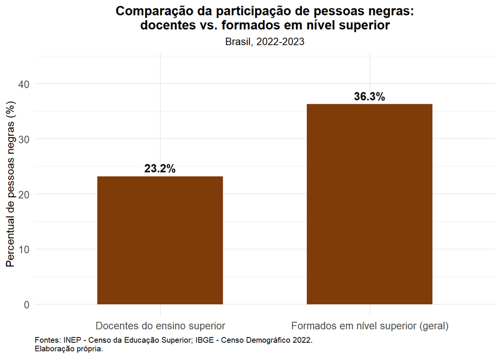

Figure 4.2: Comparação entre Docentes e Formados em Nível Superior

Esse gap de 13,1 pontos percentuais entre formados (36,3%) e docentes (23,2%) indica que, para cada pessoa negra que se torna docente universitária, há proporcionalmente mais pessoas não negras fazendo essa transição. Se a transição entre conclusão do ensino superior e docência fosse equitativa, esperaríamos encontrar proporção de docentes negros similar à proporção de negros entre os formados. A discrepância observada sugere existência de barreiras específicas ao ingresso e permanência de pessoas negras na carreira acadêmica.

Entre essas barreiras destacam-se: menor acesso a programas de pós-graduação, especialmente doutorado; dificuldades financeiras para se dedicar exclusivamente aos estudos de pós-graduação; menor inserção em redes acadêmicas que facilitam o acesso a orientadores renomados e a oportunidades de pesquisa; discriminação racial em processos seletivos para contratação; e menor reconhecimento da produção acadêmica de pesquisadores negros. Essas barreiras operam de forma cumulativa ao longo da trajetória acadêmica, produzindo o afunilamento observado.

# 5 Distribuição Regional e por Rede de Ensino

Esta seção examina como a participação de docentes negros varia entre as cinco grandes regiões brasileiras e entre as redes pública e privada, revelando importantes desigualdades territoriais e institucionais.

## 5.1 Participação de Docentes Negros por Região e Rede

A Figura 5.1 apresenta a participação de docentes negros segundo região e rede de ensino em 2024. Os resultados revelam marcantes diferenças regionais, com gradiente que acompanha a composição demográfica de cada região.

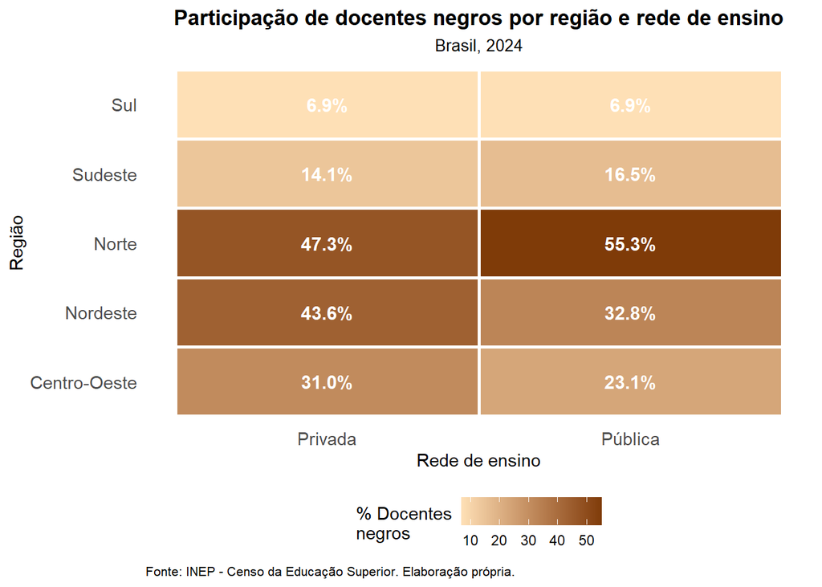

Figure 5.1: Participação de Docentes Negros por Região e Rede

A região Norte apresenta as maiores proporções de docentes negros, com 47,3% na rede privada e 55,3% na rede pública. O Nordeste registra 43,6% na rede privada e 32,8% na rede pública. O Centro-Oeste apresenta 31,0% na rede privada e 23,1% na rede pública. No Sudeste, a participação é de 14,1% na rede privada e 16,5% na rede pública. A região Sul apresenta os menores percentuais: 6,9% tanto na rede privada quanto na pública.

Esses padrões regionais refletem a composição demográfica de cada região, mas mesmo nas regiões com maior proporção de população negra (Norte e Nordeste), a representação entre docentes permanece inferior à proporção populacional. A região Norte é a única onde docentes negros ultrapassam 50% na rede pública (55,3%), aproximando-se da paridade com a composição demográfica regional. Nas demais regiões, mesmo onde a população negra é majoritária, persistem déficits significativos de representação docente.

# 6 Considerações sobre Desigualdades Raciais na Docência Universitária

Os dados analisados neste texto evidenciam persistente e acentuada sub-representação da população negra entre os docentes do ensino superior brasileiro, mesmo após década de implementação de políticas afirmativas e expansão do acesso da população negra à educação superior. Pessoas negras, que representam 56% da população brasileira, correspondem a apenas 23,2% dos docentes universitários, evidenciando desigualdade racial estrutural no acesso a posições de prestígio acadêmico.

A análise do “teto de vidro” revela dramático afunilamento da participação negra ao longo da trajetória acadêmica: de 55,5% na população geral para 23,2% entre docentes universitários. Esse afunilamento evidencia que barreiras estruturais operam em múltiplos pontos da trajetória: acesso ao ensino superior, progressão para a pós-graduação, obtenção de doutorado e, finalmente, ingresso na carreira docente. A menor proporção de docentes negros com doutorado (25,3%) em comparação aos mestres (28,2%) sugere barreiras adicionais nos níveis mais elevados da hierarquia acadêmica.

As desigualdades regionais são marcantes: enquanto a região Sul apresenta apenas 6,9% de docentes negros, o Norte alcança 55,3% na rede pública. Essas diferenças refletem a composição demográfica regional, mas mesmo nas regiões com maior população negra, a representação docente permanece inferior ao esperado. A maior participação negra na rede pública em nível nacional (23,4% vs. 23,0% na privada) sugere efeito positivo, ainda que limitado, das políticas de cotas para concursos públicos.

O recorte municipal apresentado na Seção 3 mostra que a sub-representação negra entre formados em nível superior não é um fenômeno uniforme no território: ela varia substancialmente entre municípios, mesmo dentro de uma mesma região, indicando que políticas de acesso e permanência de caráter exclusivamente nacional ou regional podem não captar a heterogeneidade local da desigualdade racial.

Em conjunto, esses resultados reforçam a necessidade de políticas abrangentes que atuem em múltiplos pontos da trajetória acadêmica: ampliação de bolsas de pós-graduação para estudantes negros; implementação efetiva de cotas raciais em concursos docentes; combate à discriminação racial em processos seletivos; fortalecimento de programas de mentoria e inserção em redes acadêmicas; e valorização da produção científica sobre relações raciais. Apenas com ações coordenadas, sensíveis também às desigualdades municipais identificadas, será possível romper o “teto de vidro” que limita a presença de pessoas negras nas posições de maior prestígio do sistema educacional brasileiro.

## Referências

BRASIL. **Lei nº 12.990, de 9 de junho de 2014**. Reserva aos negros 20% das vagas oferecidas nos concursos públicos para provimento de cargos efetivos e empregos públicos no âmbito da administração pública federal. Brasília: Diário Oficial da União, 2014.

IBGE. **Desigualdades Sociais por Cor ou Raça no Brasil**. Estudos e Pesquisas - Informação Demográfica e Socioeconômica, n. 41. Rio de Janeiro: IBGE, 2019.

INEP. **Censo da Educação Superior 2023**. Brasília: INEP, 2024.

SANTOS, Dyane Brito Reis. **A trajetória de docentes negras no labirinto de cristal**. Revista de Administração Contemporânea, v. 24, n. 3, 2020.

TELLES, Edward E. **Race in Another America: The Significance of Skin Color in Brazil**. Princeton: Princeton University Press, 2004.

IBGE. **Censo Demográfico 2022**. Rio de Janeiro: IBGE, 2023.